# Predicting Breast Cancer Outcomes from Clinical Features and Protein Biomarkers

Veerapetch Petchger, Clement Li, Heather Lu, Xiucheng (Eric) Zhang

# 1) Introduction / Motivation

Breast cancer is a major global health burden and a leading cause of cancer-related death among women. While clinical characteristics such as tumour stage and histology inform prognosis, molecular biomarkers may offer additional insight into disease progression and survival. In this project, we describe patterns of clinical features and protein biomarkers in the BRCA dataset, assess whether biomarker levels differ across patient groups, build a regression model to predict survival status, and conduct basic survival analysis to explore factors associated with follow-up outcomes.

# 2) Data

### Source and study population.

This project uses a de-identified, publicly available breast cancer dataset obtained from Kaggle (https://www.kaggle.com/datasets/amandam1/breastcancerdataset/code). The dataset includes 334 patients with primary breast cancer who underwent surgical treatment. For each patient, the file contains demographic information (age, gender), tumour characteristics (tumour stage, histology, ER/PR/HER2 receptor status), several protein biomarkers (Protein1–Protein4), treatment information (type of surgery), and follow-up data (date of surgery, date of last visit, and vital status).

Before analysis, observations with missing `patient_id` were removed, as these corresponded to empty rows at the bottom of the file. For the survival analysis, we restricted to patients with non-missing dates of surgery and last follow-up, non-missing vital status, and non-negative follow-up time, resulting in 317 patients included in the Kaplan–Meier and log-rank analyses.

### Data import and cleaning

```r
brca_df_raw = read_csv("BRCA.csv") |>
  janitor::clean_names() |>
  filter(!is.na(patient_id)) #remove empty rows at the bottom
```

#### Variables

After `clean_names()`, your key columns are:

- `patient_id`: Unique identifier for each patient.
- `age`: Age at time of surgery (years), treated as a continuous covariate.
- `gender`: Patient sex (factor).
- `protein1`–`protein4`: Continuous protein biomarker measurements.
- `tumour_stage`: Clinical tumour stage at diagnosis (I, II, III), treated as an ordered factor.
- `histology`: Histological subtype of the breast tumour (categorical).
- `er_status`: Oestrogen receptor (ER) status (e.g., Positive/Negative).
- `pr_status`: Progesterone receptor (PR) status.
- `her2_status`: HER2 receptor status.
- `surgery_type`: Type of surgery performed (e.g., lumpectomy, mastectomy).

Time variables

- Clarify outcome: patient status (Alive/Dead).
- `date_of_surgery`: Calendar date of the primary breast cancer surgery.
- `date_of_last_visit`: Date of last recorded follow-up visit.
- `patient_status`: Vital status at last follow-up (`Alive` or `Dead`).

The primary outcome for this project is **patient_status**, indicating whether the patient was alive or dead at last follow-up. For survival analysis, we use `date_of_surgery` and `date_of_last_visit` to define follow-up time (in days) and combine this with `patient_status` to create a time-to-event and censoring indicator.

#### Clean data types

```r
brca = brca_df_raw |>
  mutate( #categorical variables
    gender       = factor(gender),
    tumour_stage = factor(tumour_stage,
                          levels = c("I", "II", "III"),
                          ordered = TRUE),
    histology    = factor(histology),
    er_status    = factor(er_status),
    pr_status    = factor(pr_status),
    her2_status  = factor(her2_status),
    surgery_type = factor(surgery_type),
    patient_status = factor(patient_status,
                            levels = c("Alive", "Dead")),
    #date variables
    date_of_surgery     = as.Date(date_of_surgery, format = "%d-%b-%y"),
    date_of_last_visit  = as.Date(date_of_last_visit, format = "%d-%b-%y"),

    # survival
    follow_up_time = as.numeric(date_of_last_visit - date_of_surgery),
    event = case_when(
      patient_status == "Dead"  ~ 1L,
      patient_status == "Alive" ~ 0L,
      TRUE                      ~ NA_integer_
    )
  )
```

## 3) Exploratory Data Analysis (EDA)

## EDA 1. Summary Tables

### Patient Characteristics Summary

```r
brca %>%
  select(age, gender, tumour_stage, histology, er_status, pr_status, her2_status, surgery_type, patient_status) |>
  skimr::skim()
```

Data summary

| Name | %>%(…) |
| --- | --- |
| Number of rows | 334 |
| Number of columns | 9 |
| _______________________ |  |
| Column type frequency: |  |
| factor | 8 |
| numeric | 1 |
| ________________________ |  |
| Group variables | None |

**Variable type: factor**

| skim_variable | n_missing | complete_rate | ordered | n_unique | top_counts |
| --- | --- | --- | --- | --- | --- |
| gender | 0 | 1.00 | FALSE | 2 | FEM: 330, MAL: 4 |
| tumour_stage | 0 | 1.00 | TRUE | 3 | II: 189, III: 81, I: 64 |
| histology | 0 | 1.00 | FALSE | 3 | Inf: 233, Inf: 89, Muc: 12 |
| er_status | 0 | 1.00 | FALSE | 1 | Pos: 334 |
| pr_status | 0 | 1.00 | FALSE | 1 | Pos: 334 |
| her2_status | 0 | 1.00 | FALSE | 2 | Neg: 305, Pos: 29 |
| surgery_type | 0 | 1.00 | FALSE | 4 | Oth: 105, Mod: 96, Sim: 67, Lum: 66 |
| patient_status | 13 | 0.96 | FALSE | 2 | Ali: 255, Dea: 66 |

**Variable type: numeric**

| skim_variable | n_missing | complete_rate | mean | sd | p0 | p25 | p50 | p75 | p100 | hist |
| --- | --- | --- | --- | --- | --- | --- | --- | --- | --- | --- |
| age | 0 | 1 | 58.89 | 12.96 | 29 | 49 | 58 | 68 | 90 | ▂▇▇▅▂ |

This table summarizes the main clinical characteristics of the 334 patients in the dataset, including age, gender, tumour stage, histology, hormone receptor status, HER2 status, surgery type, and vital status at last follow up. It gives basic statistics such as the mean and spread for age, as well as counts and percentages for each category, and provides an overall picture of who is represented in this breast cancer cohort.

### Protein Biomarker Summary

```r
brca %>%
  summarise(
    across(starts_with("protein"),
           list(mean = mean, sd = sd, min = min, max = max),
           na.rm = TRUE)
  )
```

```
## # A tibble: 1 × 16
##   protein1_mean protein1_sd protein1_min protein1_max protein2_mean protein2_sd
##           <dbl>       <dbl>        <dbl>        <dbl>         <dbl>       <dbl>
## 1       -0.0300       0.564        -2.34         1.59         0.947       0.912
## # ℹ 10 more variables: protein2_min <dbl>, protein2_max <dbl>,
## #   protein3_mean <dbl>, protein3_sd <dbl>, protein3_min <dbl>,
## #   protein3_max <dbl>, protein4_mean <dbl>, protein4_sd <dbl>,
## #   protein4_min <dbl>, protein4_max <dbl>
```

This table describes the four anonymized protein biomarkers in the dataset by reporting their mean, standard deviation, and observed range. These summaries help us see the typical expression level and variability of each protein across patients, which is useful context for later modeling and group comparisons.

## EDA 2. Distribution Visualization

### Age Distribution

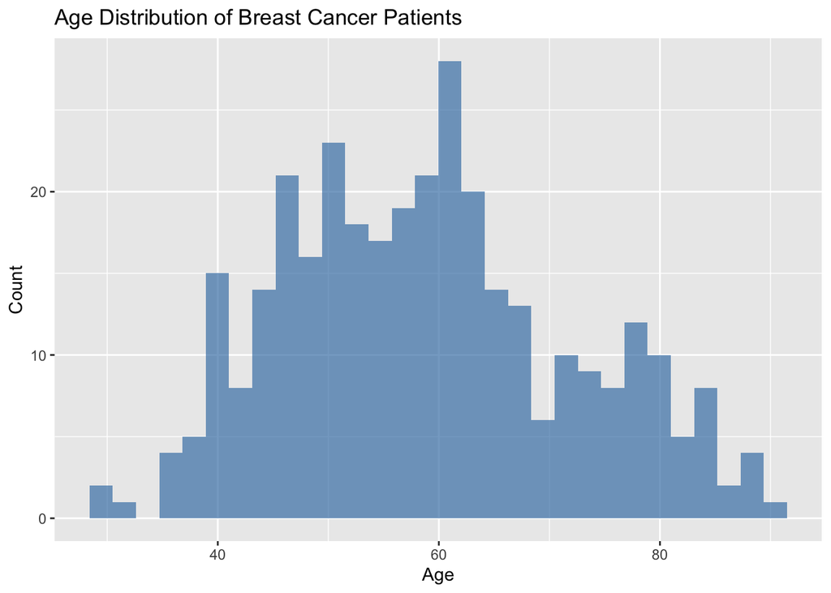

```r
brca %>%
  ggplot(aes(x = age)) +
  geom_histogram(bins = 30, fill = "steelblue", alpha = 0.7) +
  labs(title = "Age Distribution of Breast Cancer Patients",
       x = "Age", y = "Count")
```

This histogram shows how patient age is distributed in the cohort. It highlights the most common age range at diagnosis or surgery and allows us to see whether the sample is concentrated in midlife, older age, or spread more evenly across the adult lifespan.

### Protein distribution

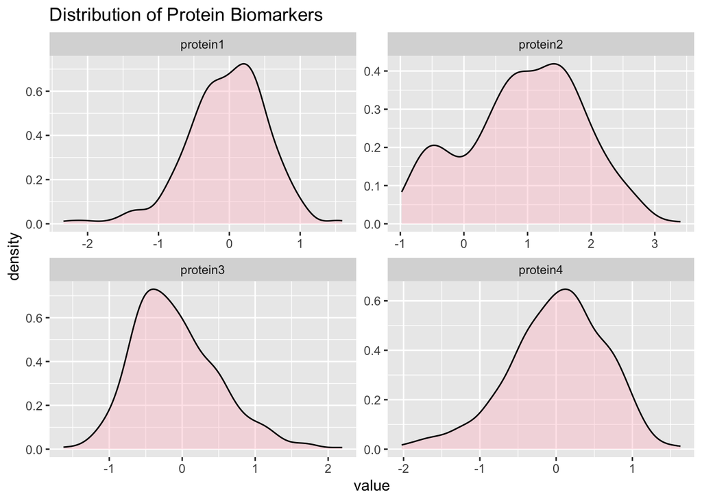

```r
brca %>%
  pivot_longer(starts_with("protein"), names_to = "protein", values_to = "value") |>
  ggplot(aes(x=value)) +
  geom_density(fill="pink", alpha=0.4) +
  facet_wrap(~protein, scales="free") +
  labs(title = "Distribution of Protein Biomarkers")
```

These density plots display the distribution of each of the four protein biomarkers across all patients. By looking at the shapes of the curves, we can see whether each biomarker is approximately symmetric or skewed, whether there are long tails, and whether any proteins appear to have multiple modes or outlying values.

## EDA 3. Classification Visulization

### Carcinoma Type Classification

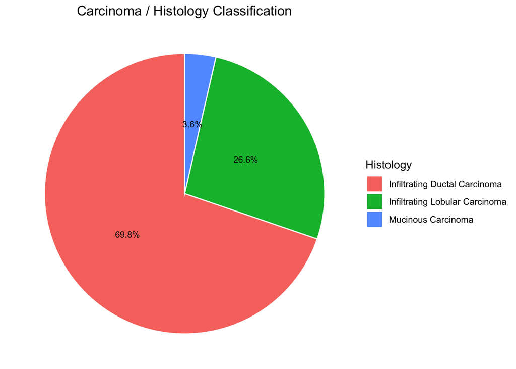

```r
carcinoma_type_pie =
  brca %>%
  count(histology) %>%
  mutate(
    prop  = n / sum(n),
    label = scales::percent(prop, accuracy = 0.1)
  ) %>%
  ggplot(aes(x = "", y = prop, fill = histology)) +
  geom_col(color = "white") +
  coord_polar(theta = "y") +
  geom_text(aes(label = label),
            position = position_stack(vjust = 0.5),
            size = 3) +
  labs(title = "Carcinoma / Histology Classification",
       fill  = "Histology") +
  theme_void() +
  theme(plot.title = element_text(hjust = 0.5))

carcinoma_type_pie
```

This pie chart summarizes the distribution of histologic tumour types in the dataset. The largest slice corresponds to infiltrating ductal carcinoma, reflecting that most patients in this cohort have IDC, while infiltrating lobular carcinoma and mucinous carcinoma make up smaller proportions. This mirrors the expected pattern in clinical practice, where IDC is the most common invasive breast cancer subtype.

Infiltrating ductal carcinoma (IDC) is the most common breast cancer type. It begins in the milk ducts and grows into the surrounding breast tissue. As it progresses, IDC can spread through the lymphatic system or bloodstream to other parts of the body.

Mucinous carcinoma is a breast cancer subtype in which tumour cells grow within mucin, the main component of mucus. Mucin normally supports healthy cell function, but in this tumour type, the mucin produced by cancer cells becomes part of the mass. Although mucinous tumours can occur elsewhere in the body, they most often appear in the breast.

Infiltrating lobular carcinoma (ILC) starts in the lobules, the glands that produce milk. Because it is an invasive cancer, it extends beyond the lobule into nearby tissue, and over time can spread to other parts of the body.

### tumour Stage Classification

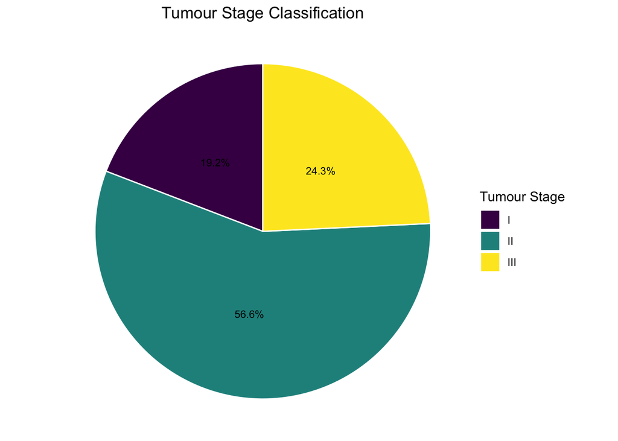

```r
tumour_stage_pie =
  brca %>%
  count(tumour_stage) %>%
  mutate(
    prop  = n / sum(n),
    label = scales::percent(prop, accuracy = 0.1)
  ) |>
  ggplot(aes(x = "", y = prop, fill = tumour_stage)) +
  geom_col(color = "white") +
  coord_polar(theta = "y") +
  geom_text(aes(label = label),
            position = position_stack(vjust = 0.5),
            size = 3) +
  labs(title = "Tumour Stage Classification",
       fill  = "Tumour Stage") +
  theme_void() +
  theme(plot.title = element_text(hjust = 0.5))

tumour_stage_pie
```

This pie chart shows how patients are distributed across tumour stages I, II, and III at the time of surgery. It allows us to see whether the dataset is dominated by early-stage disease, more advanced tumours, or a mix of both, which is important context when interpreting survival and biomarker patterns.

### General Patient Status (alive or dead)

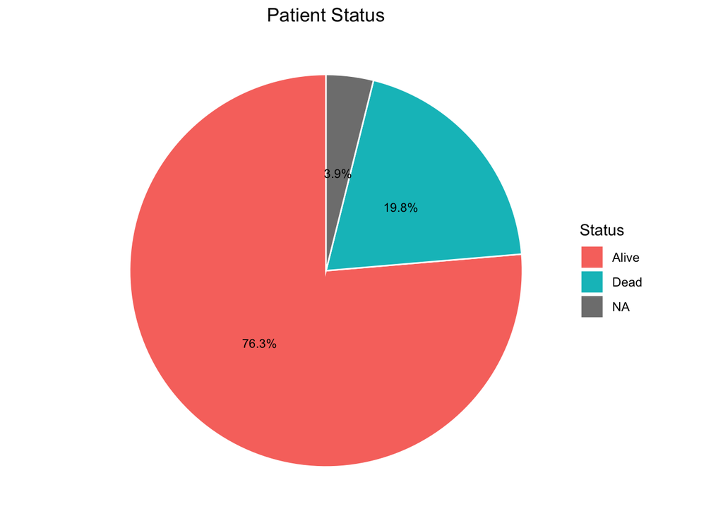

```r
general_status_pie =
  brca %>%
  count(patient_status) %>%
  mutate(
    prop  = n / sum(n),
    label = scales::percent(prop, accuracy = 0.1)
  ) %>%
  ggplot(aes(x = "", y = prop, fill = patient_status)) +
  geom_col(color = "white") +
  coord_polar(theta = "y") +
  geom_text(aes(label = label),
            position = position_stack(vjust = 0.5),
            size = 3) +
  labs(title = "Patient Status",
       fill  = "Status") +
  theme_void() +
  theme(plot.title = element_text(hjust = 0.5))

general_status_pie
```

This pie chart displays the overall proportion of patients who were alive versus dead at their last recorded visit. It provides a simple summary of outcomes in this cohort and indicates the baseline event rate that our predictive models will try to capture.

### Patient status (alive or dead) based on tumour type

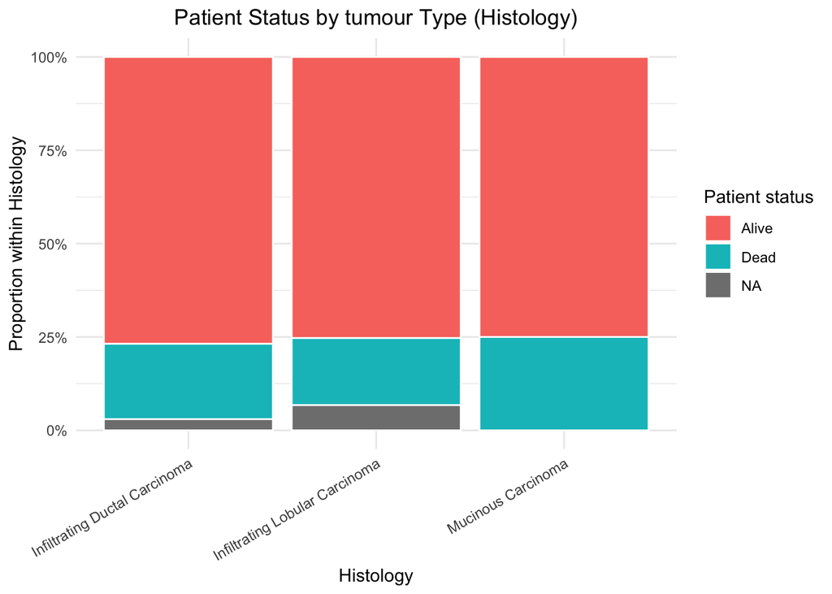

```r
histology_status_plot =
  brca %>%
  count(histology, patient_status) %>%
  group_by(histology) %>%
  mutate(prop = n / sum(n)) %>%
  ggplot(aes(x = histology, y = prop, fill = patient_status)) +
  geom_col(position = "fill", color = "white") +
  scale_y_continuous(labels = scales::percent_format(accuracy = 1)) +
  labs(
    title = "Patient Status by tumour Type (Histology)",
    x = "Histology",
    y = "Proportion within Histology",
    fill = "Patient status"
  ) +
  theme_minimal() +
  theme(
    axis.text.x = element_text(angle = 30, hjust = 1),
    plot.title = element_text(hjust = 0.5)
  )

histology_status_plot
```

This stacked bar plot shows the proportion of patients who were alive or dead within each histologic tumour type. By comparing the height of the “dead” segment across histologies, we can see whether certain carcinoma types in this sample are associated with a higher proportion of deaths. In this dataset, mucinous carcinoma appears to have a slightly higher death proportion than the other histologic groups, although the absolute number of mucinous cases is relatively small.

### Patient status (alive or dead) based on tumour stage

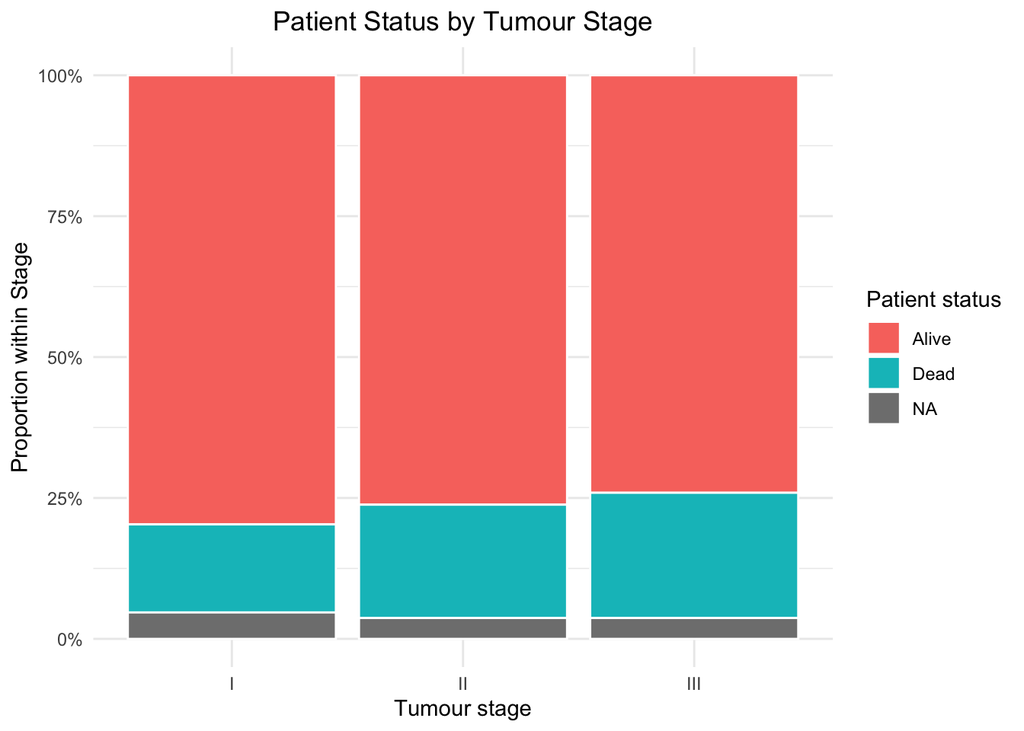

```r
tumour_stage_status_plot =
  brca %>%
  count(tumour_stage, patient_status) %>%
  group_by(tumour_stage) %>%
  mutate(prop = n / sum(n)) %>%
  ggplot(aes(x = tumour_stage, y = prop, fill = patient_status)) +
  geom_col(position = "fill", color = "white") +
  scale_y_continuous(labels = scales::percent_format(accuracy = 1)) +
  labs(
    title = "Patient Status by Tumour Stage",
    x = "Tumour stage",
    y = "Proportion within Stage",
    fill = "Patient status"
  ) +
  theme_minimal() +
  theme(
    plot.title = element_text(hjust = 0.5)
  )

tumour_stage_status_plot
```

This stacked bar plot displays the proportion of patients who were alive or dead within each tumour stage. The figure shows that the fraction of deaths increases from stage I to stage III, consistent with the clinical expectation that more advanced tumours are associated with worse outcomes. This pattern supports using tumour stage as an important predictor in subsequent survival and logistic regression analyses.

## EDA 4. Stratified Summaries

### Protein levels by tumour stage

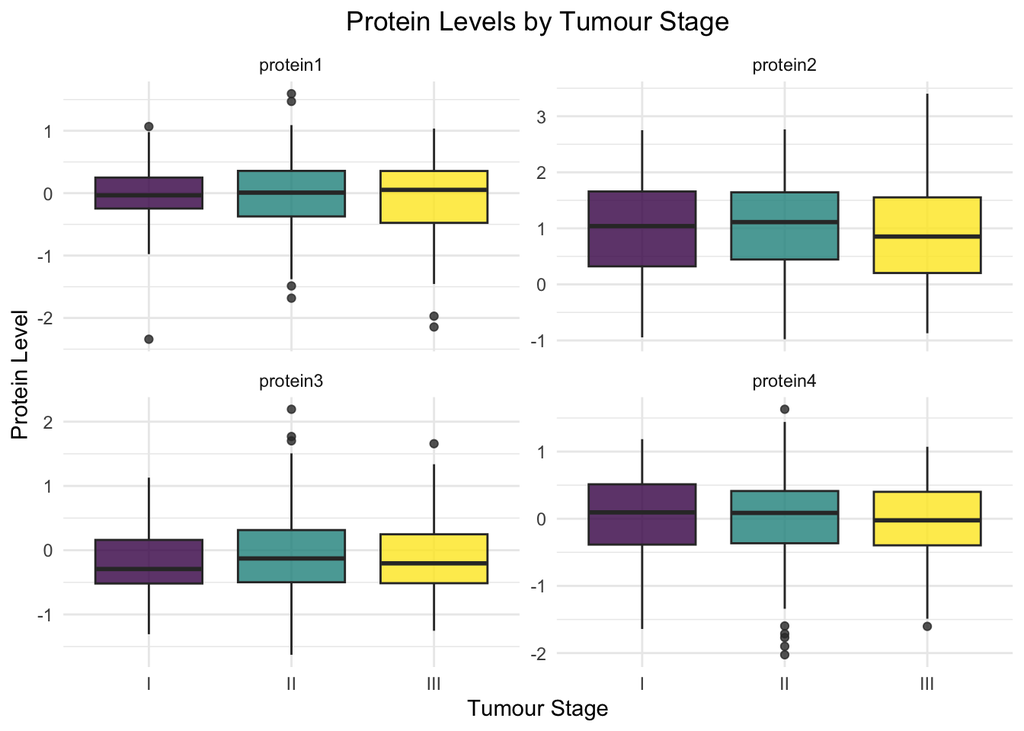

```r
brca %>%
  pivot_longer(starts_with("protein"),
               names_to = "protein",
               values_to = "value") %>%
  ggplot(aes(x = tumour_stage, y = value, fill = tumour_stage)) +
  geom_boxplot(alpha = 0.8) +
  facet_wrap(~ protein, scales = "free_y") +
  labs(
    title = "Protein Levels by Tumour Stage",
    x = "Tumour Stage",
    y = "Protein Level"
  ) +
  theme_minimal() +
  theme(
    plot.title = element_text(hjust = 0.5),
    legend.position = "none"
  )
```

This plot compares the distribution of each protein biomarker across tumour stages I, II, and III. Each protein is shown in a separate panel to make the differences easier to see. The boxplots highlight how biomarker levels change with increasing stage, allowing us to visually assess whether later-stage tumours tend to have higher or lower protein expression. This helps identify proteins that may be associated with disease progression.

### Protein levels by tumour type (histology)

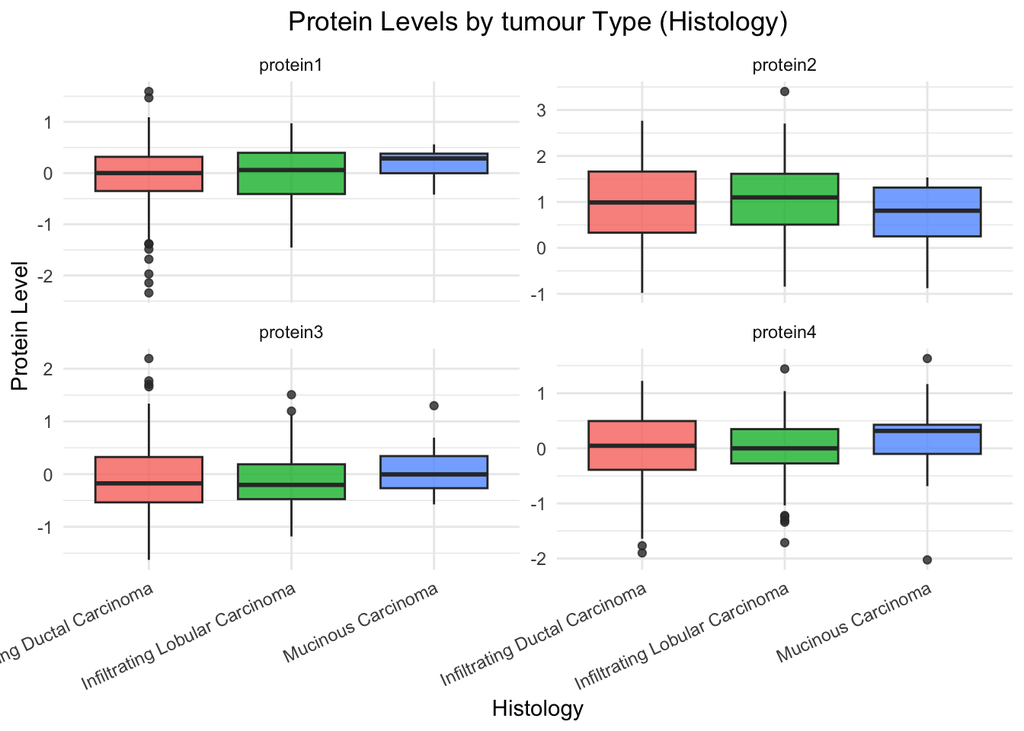

```r
brca %>%
  pivot_longer(starts_with("protein"),
               names_to = "protein",
               values_to = "value") %>%
  ggplot(aes(x = histology, y = value, fill = histology)) +
  geom_boxplot(alpha = 0.8) +
  facet_wrap(~ protein, scales = "free_y") +
  labs(
    title = "Protein Levels by tumour Type (Histology)",
    x = "Histology",
    y = "Protein Level"
  ) +
  theme_minimal() +
  theme(
    axis.text.x = element_text(angle = 25, hjust = 1),
    plot.title = element_text(hjust = 0.5),
    legend.position = "none"
  )
```

This plot shows the distribution of protein levels across the three histologic tumour types in the dataset: infiltrating ductal carcinoma, mucinous carcinoma, and infiltrating lobular carcinoma. By examining the boxplots for each protein within each histology group, we can explore whether certain biomarker patterns are more characteristic of specific tumour types. This can reveal potential diagnostic or subtype-specific differences in protein expression.

## EDA 5. Exploratory Statistical Analyses

### Summary of age by status and Two-sample t-test (Alive vs Dead)

```r
brca %>%
group_by(patient_status) %>%
summarise(
mean_age = mean(age, na.rm = TRUE),
sd_age   = sd(age, na.rm = TRUE),
n        = n()
)
```

```
## # A tibble: 3 × 4
##   patient_status mean_age sd_age     n
##   <fct>             <dbl>  <dbl> <int>
## 1 Alive              58.8   12.9   255
## 2 Dead               59.2   13.2    66
## 3 <NA>               59.2   14.3    13
```

```r
# Two-sample t-test (Alive vs Dead)

age_status_ttest =
t.test(age ~ patient_status, data = brca)

age_status_ttest
```

```
##
##  Welch Two Sample t-test
##
## data:  age by patient_status
## t = -0.19146, df = 99.37, p-value = 0.8486
## alternative hypothesis: true difference in means between group Alive and group Dead is not equal to 0
## 95 percent confidence interval:
##  -3.949756  3.254569
## sample estimates:
## mean in group Alive  mean in group Dead
##            58.80392            59.15152
```

We first compared age between patients who were alive and those who had died at last follow up. Mean age was 58.8 years among survivors and 59.2 years among those who died, with very similar standard deviations. A Welch two-sample t-test (t = −0.19, p = 0.85) showed no evidence of a difference in mean age between the two groups. Based on this, age does not appear to be a strong discriminator of survival status in this cohort, although we still consider it clinically important enough to include as a covariate in later models.

### Contingency table: tumour stage x status

```r
stage_status_tab =
brca %>%
count(tumour_stage, patient_status) %>%
tidyr::pivot_wider(
names_from  = patient_status,
values_from = n,
values_fill = 0
)

stage_status_tab
```

```
## # A tibble: 3 × 4
##   tumour_stage Alive  Dead  `NA`
##   <ord>        <int> <int> <int>
## 1 I               51    10     3
## 2 II             144    38     7
## 3 III             60    18     3
```

```r
# Chi-square test of independence

stage_status_chisq =
chisq.test(as.matrix(stage_status_tab[ , -1]))
stage_status_chisq
```

```
##
##  Pearson's Chi-squared test
##
## data:  as.matrix(stage_status_tab[, -1])
## X-squared = 1.0913, df = 4, p-value = 0.8956
```

We next examined whether survival status was associated with tumour stage using a chi-square test of independence. Counts of alive and dead patients were similar across stages I, II, and III. The chi-square test (χ² = 1.09, df = 4, p = 0.90) provided no statistical evidence that the distribution of survival status differs by stage in this dataset. This suggests that, although more advanced disease is clinically expected to have worse outcomes, our sample does not show a strong stage–mortality association, possibly due to limited sample size or follow-up time. We still retain tumour stage as a key predictor in our logistic regression because of its clear clinical relevance.

### Contingency table: histology x status

```r
histology_status_tab =
brca %>%
count(histology, patient_status) %>%
tidyr::pivot_wider(
names_from  = patient_status,
values_from = n,
values_fill = 0
)

histology_status_tab
```

```
## # A tibble: 3 × 4
##   histology                      Alive  Dead  `NA`
##   <fct>                          <int> <int> <int>
## 1 Infiltrating Ductal Carcinoma    179    47     7
## 2 Infiltrating Lobular Carcinoma    67    16     6
## 3 Mucinous Carcinoma                 9     3     0
```

```r
# Chi-square test of independence

histology_status_chisq =
chisq.test(as.matrix(histology_status_tab[ , -1]))
histology_status_chisq
```

```
##
##  Pearson's Chi-squared test
##
## data:  as.matrix(histology_status_tab[, -1])
## X-squared = 3.1484, df = 4, p-value = 0.5333
```

We also tested for an association between histologic tumour type and survival status. Infiltrating ductal carcinoma, infiltrating lobular carcinoma, and mucinous carcinoma all had broadly similar proportions of deaths. The chi-square test (χ² = 3.15, df = 4, p = 0.53) indicated no evidence that mortality differs across histology groups. This finding aligns with the stacked bar plot and suggests that histology alone is not a strong predictor of survival in this sample, although we still consider it as a descriptive variable and a potential adjustment factor in modeling.

```r
protein_cor =
  brca %>%
  select(starts_with("protein")) %>%
  cor(use = "complete.obs")

protein_cor
```

```
##            protein1    protein2    protein3   protein4
## protein1  1.0000000  0.23814130 -0.12948243 0.28034308
## protein2  0.2381413  1.00000000 -0.41582485 0.08823857
## protein3 -0.1294824 -0.41582485  1.00000000 0.06531565
## protein4  0.2803431  0.08823857  0.06531565 1.00000000
```

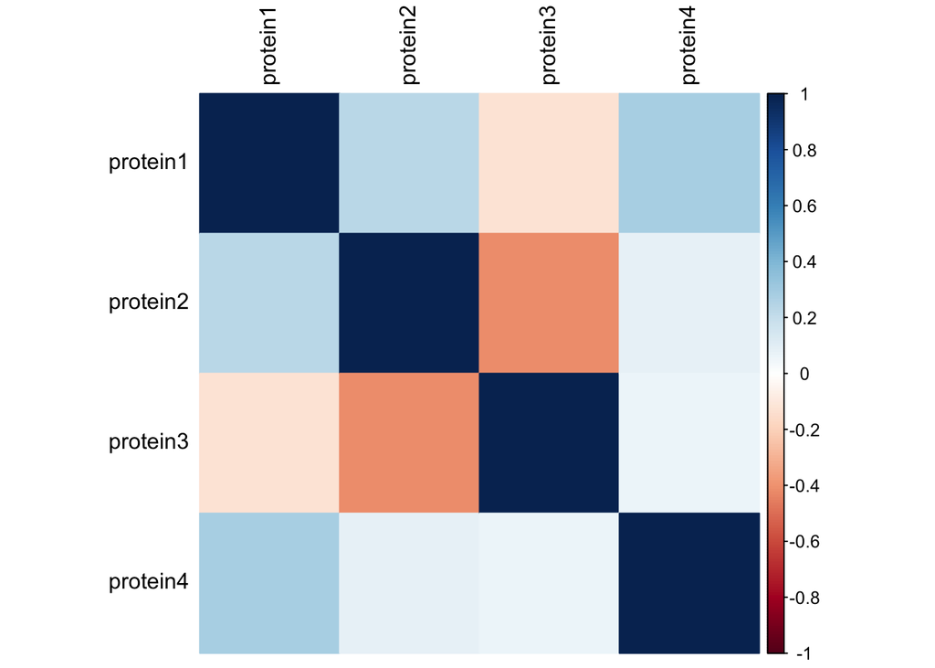

```r
corrplot(protein_cor, method = "color", tl.col = "black")
```